# Analisis Gerombol Menggunakan Algoritma K-Means

Pada tutorial ini, akan dibahas tentang langkah-langkah penggerombolan amatan menggunakan algoritma k-means dengan menggunakan software R. Ilustrasi pada tutorial ini adalah penerapan algoritma k-means untuk mengelompokkan pelanggan dari suatu perusahaan provider telepon seluler. Sebelum memulai ini, jika belum tersedia pada komputer yang Anda gunakan, Anda perlu menginstall beberapa package R yang dibutuhkan yaitu:

```r
library(cluster)
library(dplyr)
library(ggplot2)
```

### Membaca Data

Data yang digunakan merupakan data dalam format csv (comma separated values) dengan nama “customer”. Untuk menggunakannya, terlebih dahulu kita lakukan proses import data csv menjadi data frame di R menggunakan fungsi read.csv().

```r
data<-read.csv("D:/Job/E learning/regression Tree/elearning/customer.csv",sep=";")
```

Jika perintah di atas dijalankan maka kita akan memiliki sebuah data frame dengan nama data, yang memiliki 5 (lima) peubah dan 5000 amatan. Nama dan penjelasan dari masing-masing peubah adalah sebagai berikut: 1. durasi : durasi suatu nomor telepon setiap melakukan panggilan.2. REV_VOICE : jumlah biaya yang dikeluarkan untuk pemakaian panggilan suara.3. REV_SMS : jumlah biaya yang dikeluarkan untuk pemakaian SMS.4. REV_DATA : jumlah biaya yang dikeluarkan untuk pemakaian paket data.5. Rasio.on.net : Rasio penggunaan panggilan ke sesama operator.Berikut ini adalah perintah untuk mencetak 6 (enam) baris pertama dari data menggunakan fungsi head() dan hasilnya.

```r
head(data)
```

|  | durasi | REV_VOICE | Rasio.on.net | REV_SMS | REV_DATA |
| --- | --- | --- | --- | --- | --- |
| 1 | 112.00000 | 91800.00 | 1.0000000 | 9250.00 | 80.0 |
| 2 | 393.66667 | 17349.33 | 0.9366964 | 11325.00 | 29304.0 |
| 3 | 62.33333 | 30594.33 | 0.4462539 | 28150.00 | 500.0 |
| 4 | 88.66667 | 59601.67 | 0.9029147 | 12658.33 | 159001.3 |
| 5 | 1932.00000 | 253960.33 | 0.9981982 | 40175.00 | 148487.0 |
| 6 | 224.33333 | 140186.67 | 0.9250414 | 80083.33 | 180.0 |

```r
nrow(data)
```

```
## [1] 5000
```

Penggerombolan yang akan dilakukan ditujukan untuk mengidentifikasi pola perilaku pelanggan dalam menggunakan produk seluler baik berupa panggilan (voice), pesan singkat (SMS), maupun internet (paket data). Untuk itu, peubah yang nantinya akan digunakan sebagai input dalam analisis gerombol adalah: + Persentase revenue dari panggilan + Persentase revenue dari SMS + Persentase revenue dari penggunaan internet + Total durasi panggilan dalam sebulan + Persentase panggilan sesama operator + Peubah keempat dan kelima sudah tersedia, dan kita perlu melakukan transformasi untuk memperoleh peubah pertama, kedua dan ketiga. Berikut ini adalah perintah untuk melakukan hal tersebut.

```r
data$REV_VOICE1=data$REV_VOICE/(data$REV_VOICE+data$REV_SMS+data$REV_DATA)
data$REV_SMS1=data$REV_SMS/(data$REV_VOICE+data$REV_SMS+data$REV_DATA)
data$REV_DATA1=data$REV_DATA/(data$REV_VOICE+data$REV_SMS+data$REV_DATA)
data<-data[,-c(2,4,5)]
head(data)
```

|  | durasi | Rasio.on.net | REV_VOICE1 | REV_SMS1 | REV_DATA1 |
| --- | --- | --- | --- | --- | --- |
| 1 | 112.00000 | 1.0000000 | 0.9077425 | 0.09146643 | 0.0007910610 |
| 2 | 393.66667 | 0.9366964 | 0.2992382 | 0.19533159 | 0.5054301895 |
| 3 | 62.33333 | 0.4462539 | 0.5164094 | 0.47515093 | 0.0084396257 |
| 4 | 88.66667 | 0.9029147 | 0.2577243 | 0.05473606 | 0.6875396377 |
| 5 | 1932.00000 | 0.9981982 | 0.5737630 | 0.09076587 | 0.3354710977 |
| 6 | 224.33333 | 0.9250414 | 0.6359114 | 0.36327209 | 0.0008165117 |

### Eksplorasi

Sebelum kita lakukan proses clustering, kita lakukan dulu tahapan eksplorasi data untuk mengenali data yang dimiliki dengan lebih baik. Fungsi summary() dapat memberikan nilai statistik lima serangkai dan rata-rata dari setiap peubah numerik yang ada pada gugus data yang kita miliki. Berikut ilustrasi penggunaan dan hasilnya.

```r
summary(data)
```

```
##      durasi         Rasio.on.net      REV_VOICE1           REV_SMS1
##  Min.   :   0.00   Min.   :0.0000   Min.   :0.0003741   Min.   :0.000289
##  1st Qu.:  30.33   1st Qu.:0.8333   1st Qu.:0.1903481   1st Qu.:0.031065
##  Median : 113.33   Median :0.9647   Median :0.4378374   Median :0.081693
##  Mean   : 309.99   Mean   :0.8796   Mean   :0.4555666   Mean   :0.138553
##  3rd Qu.: 351.67   3rd Qu.:0.9980   3rd Qu.:0.7097808   3rd Qu.:0.190243
##  Max.   :9608.33   Max.   :1.0000   Max.   :0.9980687   Max.   :0.942564
##    REV_DATA1
##  Min.   :0.0000447
##  1st Qu.:0.0701054
##  Median :0.3761510
##  Mean   :0.4058802
##  3rd Qu.:0.7063509
##  Max.   :0.9988384
```

Perhatikan statistik deskriptif yang dihasilkan untuk peubah durasi. Peubah ini memiliki nilai maksimum yang jauh lebih besar dibandingkan kuartil ketiganya yang mengindikasikan ada beberapa pelanggan yang total durasi panggilannya jauh lebih besar dibandingkan pelanggan lain secara umum. Adanya nilai ekstrim besar ini juga yang mengakibatkan nilai mean (rata-rata) berbeda jauh dibandingkan nilai mediannya. Keberadaan pencilan (outlier) pada peubah durasi dapat dengan mudah diidentifikasi melalui grafik histogram yang dihasilkan oleh fungsi hist() seperti berikut ini. Lihat bahwa sebagian besar data bernilai kecil sehingga batang di sebelah kiri sangat dominan tingginya, namun ada batang-batang sangat kecil di bagian kanan.

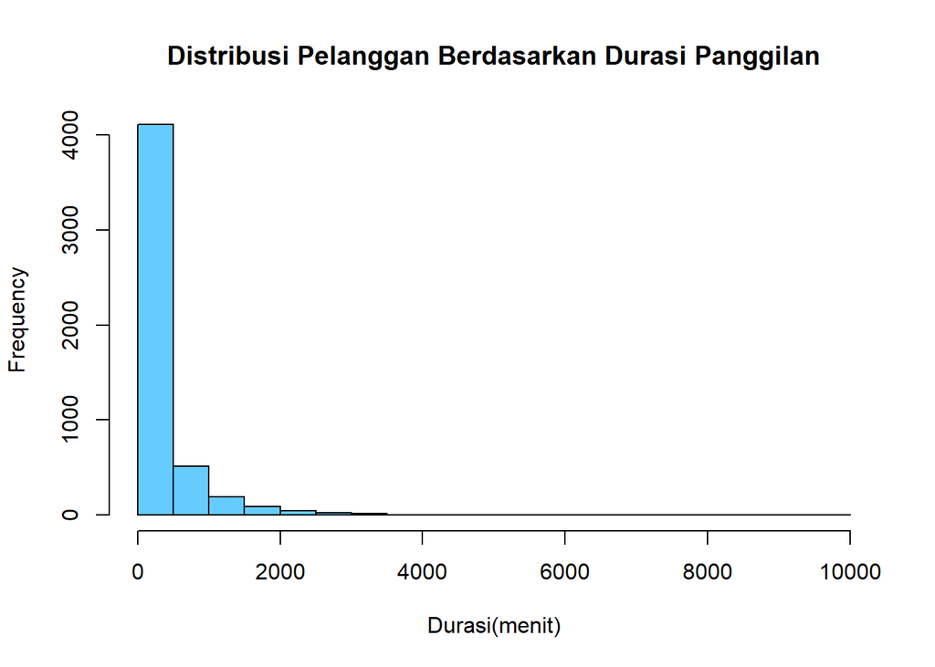

```r
hist(data$durasi,main="Distribusi Pelanggan Berdasarkan Durasi Panggilan",xlab="Durasi(menit)",breaks=20,col="#66CCFF")
```

Untuk diketahui, pada fungsi hist() terdapat beberapa opsi yang bisa kita atur atau ubah nilainya, misalnya: - main, adalah opsi untuk memberikan judul grafik yang pada ilustrasi di atas diisikan “Distribusi Pelanggan Berdasarkan Durasi Panggilan” - xlab, merupakan opti untuk memberikan label pada sumbu horizontal - breaks, merupakan opsi untuk menentukan banyaknya batang atau interval nilai data yang digambarkan distribusinya Karena adanya pencilan, kita tidak mudah membaca histogram di atas karena hampir semua nilai data termasuk pada selang nilai pertama. Untuk itu, kita dapat menggambar hanya sebagian atau subset data saja. Misalnya, berikut ini adalah menggambarkan histogram dari data durasi yang nilainya kurang dari atau sama dengan 3000 menit.

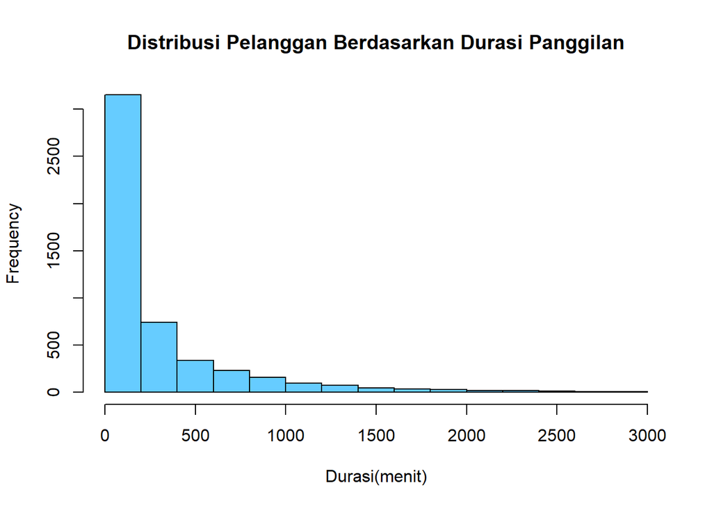

```r
hist(data$durasi[data$durasi<=3000],main="Distribusi Pelanggan Berdasarkan Durasi Panggilan",xlab="Durasi(menit)",breaks=20,col="#66CCFF")
```

Histogram sebaran nilai data dari beberapa variabel lain dapat diperoleh sebagai berikut.

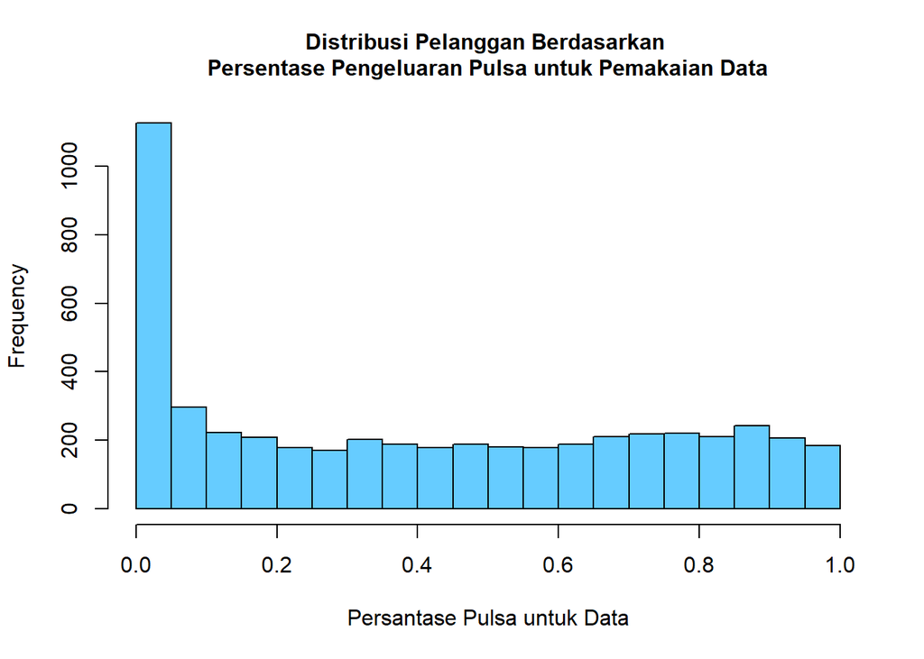

```r
par(ps = 12, cex = 1, cex.main = 1)
hist(data$REV_DATA1,main="Distribusi Pelanggan Berdasarkan \nPersentase Pengeluaran Pulsa untuk Pemakaian Data",xlab="Persantase Pulsa untuk Data",breaks=20,col="#66CCFF")
```

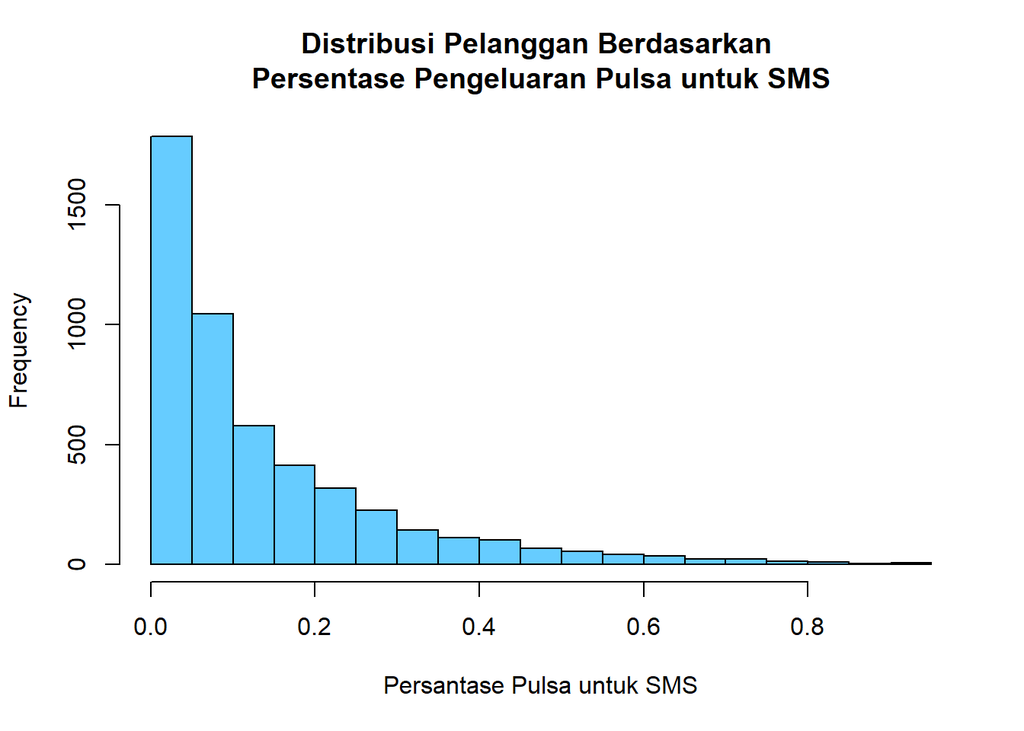

```r
hist(data$REV_SMS1,main="Distribusi Pelanggan Berdasarkan \nPersentase Pengeluaran Pulsa untuk SMS",xlab="Persantase Pulsa untuk SMS",breaks=20,col="#66CCFF")
```

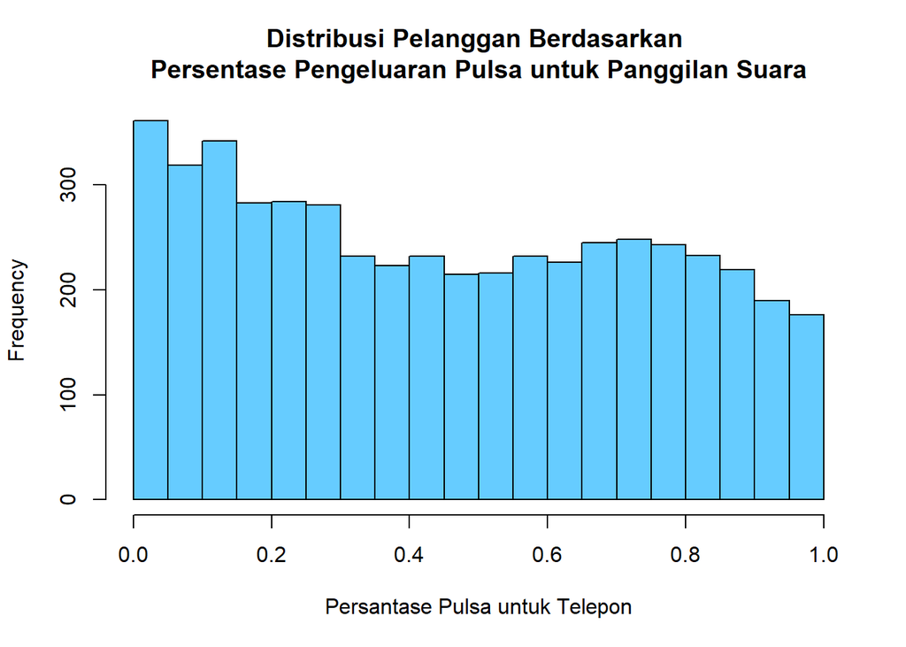

```r
hist(data$REV_VOICE1,main="Distribusi Pelanggan Berdasarkan \nPersentase Pengeluaran Pulsa untuk Panggilan Suara",xlab="Persantase Pulsa untuk Telepon",breaks=20,col="#66CCFF")
```

Informasi lain yang juga penting untuk dilihat adalah korelasi antar peubah. Korelasi ini dapat dihasilkan menggunakan fungsi cor() dan akan dihasilkan matriks korelasi berukuran 5 x 5 seperti berikut ini.

```r
cor(data)
```

```
##                   durasi Rasio.on.net  REV_VOICE1    REV_SMS1  REV_DATA1
## durasi        1.00000000    0.2426033  0.36390627 -0.01312864 -0.3187430
## Rasio.on.net  0.24260330    1.0000000  0.20154811  0.11244990 -0.2330108
## REV_VOICE1    0.36390627    0.2015481  1.00000000 -0.02352877 -0.8818126
## REV_SMS1     -0.01312864    0.1124499 -0.02352877  1.00000000 -0.4507214
## REV_DATA1    -0.31874304   -0.2330108 -0.88181262 -0.45072141  1.0000000
```

Terlihat bahwa persentase penghasilan untuk panggilan berkorelasi negatif dengan persentase penghasilan dari penggunaan paket data internet (korelasi = -0.88) yang mengindikasikan bahwa semakin banyak penggunaan internet pelanggan maka penggunaan panggilan akan berkurang, dan demikian pula sebaliknya. Sedangkan penghasilan dari panggilan dan SMS relatif tidak berkorelasi (korelasi = -0.02). Seperti yang dapat dipahami secara intuitif, peubah durasi panggilan memiliki korelasi yang positif dengan penghasilan dari panggilan. Nilai korelasi yang tidak terlalu besar dapat dimengerti karena provider menyediakan paket-paket promo panggilan sehingga pelanggan dapat melakukan panggilan berdurasi lama tetapi harganya murah, tapi ada juga pelanggan yang melakukan panggilan tanpa mengaktifkan paket promo.

### Pembakuan data

Tujuan dari proses penggerombolan adalah mengelompokkan objek dengan karakter yang mirip ke dalam sebuah gerombol dan objek dengan karakteristik yang berbeda ditempatkan di gerombol yang lain. Kemiripan antar objek dapat diukur dengan menggunakan jarak euclidean yang dihitung dengan formula:
$$d_{ij} = \sqrt{\sum_{k=1}^{n}(x_{ik} - x_{jk})^2 }$$
Hasil dari perhitungan jarak sangat tergantung pada skala dari peubah yang digunakan. Dalam banyak hal, disarankan untuk melakukan pembakuan data sehingga kontribusi setiap peubah dalam perhitungan jarak menjadi lebih berimbang. Proses pembakuan data dapat dilakukan dengan perintah berikut:

```r
baku<-scale(data)
head(baku)
```

```
##          durasi Rasio.on.net REV_VOICE1   REV_SMS1  REV_DATA1
## [1,] -0.3650621    0.6734561  1.5431837 -0.3041755 -1.2344382
## [2,]  0.1542950    0.3193462 -0.5335167  0.3667815  0.3033613
## [3,] -0.4566410   -2.4241094  0.2076442  2.1743824 -1.2111305
## [4,] -0.4080857    0.1303765 -0.6751952 -0.5414495  0.8583080
## [5,]  2.9907838    0.6633771  0.4033802 -0.3087011 -0.2145593
## [6,] -0.1579338    0.2541500  0.6154799  1.4516580 -1.2343606
```

## Penerapan K-means

Algoritma k-means memerlukan pengguna menentukan berapa banyak gerombol yang akan dibentuk. Pada ilustrasi ini secara subjektif kita akan tentukan bahwa gerombol yang dibentuk adalah 3 (tiga) dan kemudian nanti akan dipaparkan bagaimana memperoleh banyaknya gerombol optimal dari data yang ada. Berikut ini adalah ilustrasi penggunaan fungsi kmeans() untuk menghasilkan 3 gerombol. Ingat bahwa gugus data yang digunakan adalah gugus data yang peubahnya telah dibakukan.

```r
library(cluster)
set.seed(123)
kluster<-kmeans(baku,3)
```

Selanjutnya menarik untuk melihat hasil kerja algoritma k-means di atas. Pertama kita bisa menampilkan berapa banyaknya anggota dari masing-masing gerombol. Perintah yang dapat diberikan adalah

```r
kluster$size
```

```
## [1]  693 2070 2237
```

Terlihat bahwa dari 5000 pelanggan, terdapat 693 pelanggan yang dimasukkan ke dalam gerombol pertama, 2070 pelanggan di gerombol kedua, dan 2237 pelanggan di gerombol ketiga. Apa itu gerombol pertama, kedua, dan ketiga? Pertanyaan ini dapat kita jawab melalui proses profiling dengan melihat rata-rata dari masing-masing peubah di setiap gerombol. Nilai ini tidak lain adalah centroid atau center dari gerombol yang dapat dilihat dengan perintah berikut ini.

```r
kluster$centers #diceritakan
```

```
##       durasi Rasio.on.net REV_VOICE1   REV_SMS1  REV_DATA1
## 1 -0.2565974    0.1621910 -0.2553536  2.0217355 -0.7257061
## 2  0.5009901    0.2789015  0.9926908 -0.1638389 -0.8090976
## 3 -0.3840981   -0.3083256 -0.8394769 -0.4747055  0.9735120
```

Pembacaan hasil di atas memang agak “tricky” karena rata-rata yang ditampilkan berasal dari peubah yang sudah dibakukan. Peubah yang dibakukan ini bernilai negatif kalau nilai asalnya kecil dan akan positif kalau nilai asalnya besar. Lihat misalnya cluster pertama, memiliki nilai REV_SMS1 yang lebih besar dibandingkan cluster lain dan REV_VOICE1 serta REV_DATA1 yang negatif. Durasi menelepon juga negatif. Ini mengindikasikan bahwa 693 pelanggan di gerombol pertama ini memiliki karakteristik persentase SMS yang dominan. Kita barangkali dapat memberi label gerombol pertama sebagai “SMS mania” karena hal tersebut. Sekarang lihat cluster kedua. Pelanggan di gerombol ini memiliki rata-rata durasi menelepon yang lebih besar dibanding gerombol yang lain dan tentu saja juga REV_VOICE1 yang lebih tinggi. Gerombol ini dapat kita labeli sebagai gerombol “CALL mania”. Sementara gerombol ketiga tampaknya diisi oleh pelanggan pemakai aktif internet. Seberapa baik hasil clustering di atas? Salah satu indikasi yang dapat digunakan adalah dengan melihat indeks silhouette yang merupakan perbandingan antara jarak objek antar gerombol dengan jarak objek dalam gerombol. Semakin besar nilai indeks ini mengindikasikan semakin baik hasil clustering yang diperoleh. Nilai indeks silhouette dari hasil penggerombolan di atas adalah sebesar 1885. 76 yang diperoleh menggunakan perintah berikut.

```r
jarak<-dist(baku)
sk <- silhouette(kluster$cl, jarak)
nilaisk<-sum(sk[,3])
nilaisk
```

```
## [1] 1885.763
```

### Penentuan Banyaknya Kluster Optimal

Untuk mengetahui apakah hasil penggerombolan 5000 pelanggan menjadi 3 gerombol sudah baik, kita dapat melakukan pemeriksaan dengan menghitung indeks silhouette untuk berbagai banyaknya gerombol. Berikut ini adalah program untuk menghasilkan nilai indeks untuk gerombol sebanyak 2 sampai dengan 20, dan kemudian menampilkannya dalam bentuk plot. Nilai indeks paling besar dihasilkan ketika ada 5 gerombol, sehingga k=5 adalah yang optimal.

```r
set.seed(123)
jarak<-dist(baku)
sk<-NULL
for(k in 2:20){
kluster<-kmeans(baku,k)
sk <- silhouette(kluster$cl, jarak)
nilaisk[k-1]<-sum(sk[,3])
}
nilaisk
```

```
##  [1] 1788.603 1885.158 1904.981 1948.327 1509.356 1520.388 1496.903
##  [8] 1628.653 1640.103 1596.714 1573.160 1459.478 1488.998 1447.171
## [15] 1373.742 1451.801 1370.007 1394.845 1459.662
```

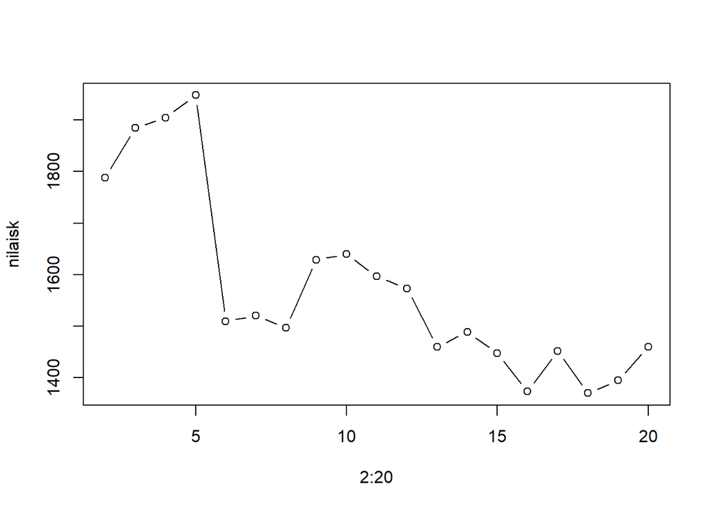

```r
plot(2:20,nilaisk,type='b')
```

Selain menggunakan indeks silhouette, kita dapat pula menggunakan ukuran lain yaitu rasio antara jumlah kuadrat dalam cluster dengan jumlah kuadrat antar cluster. Hasil yang baik tentunya yang memberikan nilai rendah. Jika perubahan dari satu nilai k ke nilai k lain sudah kecil, maka kita bisa menyimpulkan itu adalah nilai k yang optimal. Berikut ini program untuk menghasilkan nilai tersebut dan menampilkan plotnya. Tampak bahwa perubahan nilai dari k=5 ke k=6 sudah sangat kecil, sehingga kita juga dapat mengatakan bahwa pemilihan k=5 cukup beralasan.

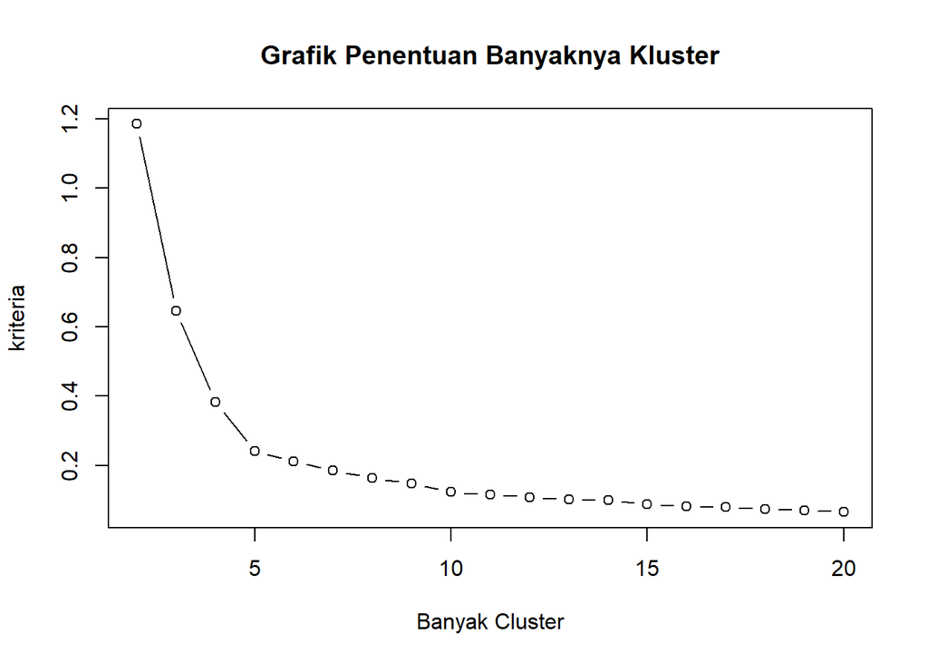

```r
seed=123
banyakcluster=2:20
kriteria=NULL
for(i in banyakcluster){
set.seed(seed)
kluster<-kmeans(baku[,-3],i)
kriteria[i-1]=kluster$tot.withinss/kluster$betweenss/banyakcluster
}
plot(banyakcluster,kriteria,type="b",xlab="Banyak Cluster", Ylab="kriteria",main="Grafik Penentuan Banyaknya Kluster")
```

### Hasil Akhir Penggerombolan

Jadi, berdasarkan nilai sillhoute dan rasio jumlah kuadrat, kita dapatkan bahwa banyaknya gerombol (k) optimum adalah 5. Untuk itu, kita lakukan proses clustering menggunakan k-means dengan k=5 sebagai berikut.

```r
set.seed(123)
hasil<-kmeans(baku,5)
```

Untuk memudahkan interpretasi cluster/gerombol yang dihasilkan, hasil dari prosedur k-means kita gabungkan dengan data asli sebagai berikut sehingga kode cluster kita letakkan sebagai kolom terakhir pada data.

```r
dat.hasil<-data.frame(cbind(data,hasil$cluster))
head(dat.hasil)
```

|  | durasi | Rasio.on.net | REV_VOICE1 | REV_SMS1 | REV_DATA1 | hasil.cluster |
| --- | --- | --- | --- | --- | --- | --- |
| 1 | 112.00000 | 1.0000000 | 0.9077425 | 0.09146643 | 0.0007910610 | 2 |
| 2 | 393.66667 | 0.9366964 | 0.2992382 | 0.19533159 | 0.5054301895 | 3 |
| 3 | 62.33333 | 0.4462539 | 0.5164094 | 0.47515093 | 0.0084396257 | 1 |
| 4 | 88.66667 | 0.9029147 | 0.2577243 | 0.05473606 | 0.6875396377 | 3 |
| 5 | 1932.00000 | 0.9981982 | 0.5737630 | 0.09076587 | 0.3354710977 | 4 |
| 6 | 224.33333 | 0.9250414 | 0.6359114 | 0.36327209 | 0.0008165117 | 1 |

Banyaknya anggota setiap cluster/gerombol dan rata-rata maasing-masing peubah dari setiap gerombol dapat dihasilkan menggunakan perintah berikut. fumgsi group_by() berguna untuk mengelompokkan

```r
table(dat.hasil$hasil.cluster)
```

```
##
##    1    2    3    4    5
##  620 1777 1696  287  620
```

```r
grup<-group_by(dat.hasil, hasil.cluster)
data.frame(grup%>%summarise(rataan_durasi = mean(durasi),rataan_rasio=mean(Rasio.on.net),
                 rataan_data = mean(REV_DATA1),
                 rataan_voice=mean(REV_VOICE1),rataan_sms=mean(REV_SMS1)))
```

| hasil.cluster | rataan_durasi | rataan_rasio | rataan_data | rataan_voice | rataan_sms |
| --- | --- | --- | --- | --- | --- |
| 1 | 172.8022 | 0.9149400 | 0.1572551 | 0.3727036 | 0.47004124 |
| 2 | 351.7008 | 0.9305109 | 0.1339580 | 0.7498284 | 0.11621364 |
| 3 | 126.8817 | 0.9328118 | 0.7240555 | 0.2045401 | 0.07140441 |
| 4 | 1991.8688 | 0.9785405 | 0.1638695 | 0.7144386 | 0.12169187 |
| 5 | 49.9457 | 0.5070432 | 0.6755331 | 0.2618836 | 0.06258326 |

Berdasarkan output di atas, ringkasan profil dari masing-masing gerombol adalah sebagai berikut: Gerombol #1: aktif menggunakan SMS dan panggilan, tapi sedikit internet Gerombol #2: sangat aktif melakukan panggilan Gerombol #3: sangat aktif menggunakan internet dan kadang-kadang menelepon Gerombol #4: sangat aktif melakukan panggilan dengan durasi yang panjang Gerombol #5: sangat aktif menggunakan internet, sesekali menelepon tadi tidak lama durasinya.

Demikian penjelasan tentang algoritma k-means dan penerapannya. Jika ada pertanyaan, saran serta masukan, dapat disampaikan kepada Departemen Statistika FMIPA IPB melalui email: statistika@ipb.ac.id